# Chess Elo Prediction — Multi-Model Regression Workbench

Rebuilt from `chess_elo_v_final_copy.ipynb`, using features from `chess_features_final.py`.

**What this notebook does**

1. Loads Lichess `.pgn.zst`, extracts clock + board features (same pipeline as before).
2. **Exploratory data analysis / statistics** an applied-ML grader expects (distributions, missingness, correlations, leakage check, multicollinearity).
3. **Compares 3–5 regression models** through one interface, with cross-validation (mean ± std) + a dummy baseline.
4. **Optional hyperparameter search** (RandomizedSearchCV, with a fast successive-halving option for the slow case).
5. **Diagnostics**: predicted-vs-actual, residual plots, error-by-Elo-band, learning curve.
6. **Feature-ranking comparison across time controls** (the headline experiment).
7. **Saves outputs** to a results folder and exports the whole executed notebook to HTML.

Everything is driven from the single CONFIG cell.

```python
# pip install chess zstandard lightgbm xgboost pandas scikit-learn matplotlib seaborn joblib
import io, re, time, os, json, warnings
from datetime import datetime

import numpy as np
import pandas as pd
import matplotlib.pyplot as plt
import zstandard as zstd
from joblib import Parallel, delayed

from sklearn.compose import ColumnTransformer
from sklearn.impute import SimpleImputer
from sklearn.pipeline import Pipeline
from sklearn.preprocessing import OneHotEncoder, StandardScaler
from sklearn.model_selection import train_test_split, cross_validate, KFold, RandomizedSearchCV, learning_curve
from sklearn.metrics import mean_absolute_error, root_mean_squared_error, r2_score
from sklearn.inspection import permutation_importance
from sklearn.dummy import DummyRegressor
from sklearn.linear_model import Ridge
from sklearn.ensemble import RandomForestRegressor, HistGradientBoostingRegressor
from scipy.stats import randint, uniform

import lightgbm as lgb
try:
    import xgboost as xgb
    HAS_XGB = True
except Exception:
    HAS_XGB = False

try:
    import seaborn as sns
    HAS_SNS = True
except Exception:
    HAS_SNS = False

from chess_features_final import extract_features_dataframe, compute_elo_sample_weights

warnings.filterwarnings('ignore', message='X does not have valid feature names')
print('All imports OK  |  XGBoost:', HAS_XGB, ' | seaborn:', HAS_SNS)
```

```
All imports OK  |  XGBoost: True  | seaborn: False
```

## 0 · CONFIG — edit everything here

```python
DATA_PATH    = '../../data/villads_data/lichess_db_standard_rated_2017-11.pgn.zst'
MAX_GAMES    = 300_000          # lower while iterating; raise for final run
RANDOM_STATE = 42
N_JOBS       = -1

TARGET       = 'WhiteElo'       # 'WhiteElo' or 'BlackElo'
VAL_SIZE     = 0.10
TEST_SIZE    = 0.10

# Time control for the MAIN run. Set None to keep all. Base seconds from TimeControl (e.g. 600).
FILTER_BASE_SECONDS = 600
# Time controls compared in the feature-ranking experiment (section 8).
TIME_CONTROLS_TO_COMPARE = [60, 180, 600]   # bullet, blitz, rapid

# data quality filters
MIN_TOTAL_PLIES      = 12
EXCLUDE_TERMINATIONS = {'Abandoned', 'Unterminated'}

# feature groups (board features come from chess_features_final.py)
FEATURE_GROUPS = {
    'structure': True, 'checks': True, 'captures': True, 'castling': True,
    'style': True, 'clock': True, 'engine': False, 'meta': False,
}
ADD_TIME_CONTROL_NUMERIC = True

# IMPORTANT leakage note: result_encoded / material_balance_end are outcome-related,
# not skill-related. Toggle this to drop them and avoid leaking the game result.
DROP_RESULT_LEAKAGE = True

# which models to compare
MODELS_TO_RUN = ['dummy', 'ridge', 'random_forest', 'hist_gbm', 'lightgbm']
if HAS_XGB:
    MODELS_TO_RUN.append('xgboost')

# cross-validation for the model bake-off
CV_FOLDS = 4

# hyperparameter search (slow — toggle on only when tuning)
RUN_HYPERPARAM_SEARCH = False
HYPERPARAM_MODEL      = 'lightgbm'   # which model to tune
HYPERPARAM_N_ITER     = 25
HYPERPARAM_CV_FOLDS   = 3
# 'halving' is much faster than 'random' on big data; 'random' is the classic.
HYPERPARAM_STRATEGY   = 'halving'    # 'halving' or 'random'
# Sub-sample rows for the search to keep it tractable (None = use all train rows).
HYPERPARAM_MAX_ROWS   = 80_000

# importance / diagnostics
PERM_N_REPEATS = 5
TOP_N_FEATURES = 20

# output
RESULTS_DIR = 'results'
EXPORT_HTML = True              # run nbconvert at the end
NOTEBOOK_NAME = 'chess_elo_prediction.ipynb'
os.makedirs(RESULTS_DIR, exist_ok=True)
_TS = datetime.now().strftime('%Y%m%d_%H%M%S')
print('Config loaded. Run tag:', _TS)
```

```
Config loaded. Run tag: 20260608_110616
```

## 1 · Load data (fast loader) + reusable helpers

```python
_CLK_RE = re.compile(r'\[%clk\s+(\d+):(\d+):(\d+)\]')

def parse_clock_features(moves_string, time_control='?'):
    clocks = [int(h)*3600 + int(m)*60 + int(s) for h, m, s in _CLK_RE.findall(moves_string)]
    clk_w, clk_b = clocks[0::2], clocks[1::2]
    tc_m  = re.match(r'(\d+)\+(\d+)', str(time_control))
    base  = int(tc_m.group(1)) if tc_m else None
    inc   = int(tc_m.group(2)) if tc_m else 0
    norm  = base if base else 1
    def _spent(seq, start):
        out, prev = [], start
        for c in seq:
            if prev is not None:
                s = prev - c + inc
                if s >= 0: out.append(s)
            prev = c
        return out
    sw, sb = _spent(clk_w, base), _spent(clk_b, base)
    def _stats(seq):
        if not seq: return 0., 0., 0.
        a = np.array(seq); return float(a.mean()), float(a.std()), float(a.max())
    def _trend(seq):
        if len(seq) < 2: return 0.0
        return float(np.polyfit(np.arange(len(seq)), np.array(seq, float), 1)[0])
    def _win(seq, n=10, which='first'):
        if not seq: return 0.0
        return float(np.mean(seq[:n])) if which == 'first' else float(np.mean(seq[-n:]))
    aw, sw2, mw = _stats(sw); ab, sb2, mb = _stats(sb)
    return {
        'avg_time_norm_white': aw/norm, 'std_time_norm_white': sw2/norm, 'max_time_norm_white': mw/norm,
        'time_pressure_white': sum(1 for c in clk_w if c < 10),
        'opening_pace_norm_white': (np.mean(sw[:10]) if sw else 0.)/norm,
        'clock_remaining_norm_white': (clk_w[-1]/norm) if clk_w else 0.,
        'opening_time_norm_white': _win(sw,10,'first')/norm, 'endgame_time_norm_white': _win(sw,10,'last')/norm,
        'time_spent_trend_norm_white': _trend(sw)/norm,
        'avg_time_norm_black': ab/norm, 'std_time_norm_black': sb2/norm, 'max_time_norm_black': mb/norm,
        'time_pressure_black': sum(1 for c in clk_b if c < 10),
        'opening_pace_norm_black': (np.mean(sb[:10]) if sb else 0.)/norm,
        'clock_remaining_norm_black': (clk_b[-1]/norm) if clk_b else 0.,
        'opening_time_norm_black': _win(sb,10,'first')/norm, 'endgame_time_norm_black': _win(sb,10,'last')/norm,
        'time_spent_trend_norm_black': _trend(sb)/norm,
    }

def load_games(path, max_games):
    games, dctx = [], zstd.ZstdDecompressor()
    t0 = time.time()
    with open(path, 'rb') as cf:
        with dctx.stream_reader(cf) as reader:
            stream = io.TextIOWrapper(reader, encoding='utf-8')
            cur = {}
            for line in stream:
                line = line.strip()
                if line.startswith('['):
                    tag = line.split(' ')[0][1:]
                    if tag in ('WhiteElo','BlackElo','TimeControl','ECO','Termination','Result'):
                        cur[tag] = line.split('"')[1]
                elif line.startswith('1.'):
                    cur['Moves'] = line
                    if 'WhiteElo' in cur and 'BlackElo' in cur:
                        games.append(cur)
                    cur = {}
                    if len(games) >= max_games:
                        break
    df = pd.DataFrame(games)
    for c in ('WhiteElo','BlackElo'):
        df[c] = pd.to_numeric(df[c], errors='coerce')
    df = df.dropna(subset=['WhiteElo','BlackElo']).copy()
    df['WhiteElo'] = df['WhiteElo'].astype(int)
    df['BlackElo'] = df['BlackElo'].astype(int)
    df['Moves'] = df['Moves'].fillna('').astype(str)
    print(f'Loaded {len(df):,} games in {time.time()-t0:.1f}s')
    return df

df_all = load_games(DATA_PATH, MAX_GAMES)
df_all.head(3)
```

```
Loaded 300,000 games in 11.2s
```

|  | Result | WhiteElo | BlackElo | ECO | TimeControl | Termination | Moves |
| --- | --- | --- | --- | --- | --- | --- | --- |
| 0 | 0-1 | 1391 | 1411 | C20 | 600+0 | Normal | 1. e4 { [%clk 0:10:00] } e5 { [%clk 0:05:00] }... |
| 1 | 0-1 | 1626 | 1620 | B56 | 180+0 | Time forfeit | 1. e4 { [%clk 0:03:00] } c5 { [%clk 0:03:00] }... |
| 2 | 1-0 | 1374 | 1350 | B30 | 600+0 | Normal | 1. e4 { [%clk 0:10:00] } c5 { [%clk 0:05:00] }... |

## 2 · Feature-building pipeline (reusable for the time-control experiment)

```python
_BOARD_FEATURES = {
    'structure': ['total_ply_count', 'material_balance_end', 'result_encoded'],
    'checks':    ['checks_given_white','checks_given_black','check_density_white','check_density_black'],
    'captures':  ['first_capture_move_white','first_capture_move_black','pawn_captures_total','piece_captures_total','capture_density'],
    'castling':  ['castle_move_white','castle_move_black'],
    'style':     ['consec_same_piece_white','consec_same_piece_black','queen_moves_before_10','white_territory_depth','black_territory_depth','promotions','en_passant_captures','legal_moves_white_move5','legal_moves_black_move5'],
    'engine':    ['acpl_white','inaccuracy_count_white','mistake_count_white','blunder_count_white','blunder_density_white','acpl_black','inaccuracy_count_black','mistake_count_black','blunder_count_black','blunder_density_black'],
}
_CLOCK_FEATURES = [
    'avg_time_norm_white','std_time_norm_white','max_time_norm_white','time_pressure_white','opening_pace_norm_white','clock_remaining_norm_white','opening_time_norm_white','endgame_time_norm_white','time_spent_trend_norm_white',
    'avg_time_norm_black','std_time_norm_black','max_time_norm_black','time_pressure_black','opening_pace_norm_black','clock_remaining_norm_black','opening_time_norm_black','endgame_time_norm_black','time_spent_trend_norm_black',
]
_LEAKY = {'result_encoded', 'material_balance_end'}

def active_feature_lists(feature_groups, drop_leakage):
    num, cat = [], []
    for grp, cols in _BOARD_FEATURES.items():
        if feature_groups.get(grp, False):
            num += cols
    if feature_groups['clock']:
        num += _CLOCK_FEATURES
    if ADD_TIME_CONTROL_NUMERIC:
        num += ['tc_base', 'tc_increment']
    if feature_groups['castling']:
        cat += ['castle_side_white', 'castle_side_black']
    if drop_leakage:
        num = [c for c in num if c not in _LEAKY]
    return num, cat

def build_feature_frame(df_raw, feature_groups, filter_base_seconds):
    """Filter -> clock features -> board features -> merged feature frame."""
    df_raw = df_raw.copy()
    if filter_base_seconds is not None:
        base = df_raw['TimeControl'].astype(str).str.extract(r'^(\d+)\+')[0].astype(float)
        df_raw = df_raw[base == filter_base_seconds].copy().reset_index(drop=True)
    if EXCLUDE_TERMINATIONS and 'Termination' in df_raw.columns:
        df_raw = df_raw[~df_raw['Termination'].isin(EXCLUDE_TERMINATIONS)].copy().reset_index(drop=True)
    if ADD_TIME_CONTROL_NUMERIC and 'TimeControl' in df_raw.columns:
        tc = df_raw['TimeControl'].astype(str).str.extract(r'^(\d+)\+(\d+)')
        df_raw['tc_base'] = pd.to_numeric(tc[0], errors='coerce').fillna(0).astype(float)
        df_raw['tc_increment'] = pd.to_numeric(tc[1], errors='coerce').fillna(0).astype(float)
    if len(df_raw) == 0:
        return df_raw
    # clock
    if feature_groups['clock']:
        tc_col = df_raw['TimeControl'] if 'TimeControl' in df_raw.columns else ['?']*len(df_raw)
        recs = Parallel(n_jobs=N_JOBS)(delayed(parse_clock_features)(m, t) for m, t in zip(df_raw['Moves'], tc_col))
        df_clocks = pd.DataFrame(recs, index=df_raw.index)
    else:
        df_clocks = pd.DataFrame(index=df_raw.index)
    # board
    df_feats = extract_features_dataframe(df_raw, n_jobs=N_JOBS)
    meta = ['WhiteElo','BlackElo']
    if ADD_TIME_CONTROL_NUMERIC:
        meta += ['tc_base','tc_increment']
    meta = [c for c in dict.fromkeys(meta) if c in df_raw.columns]
    df = df_raw[meta].join(df_feats, how='inner').join(df_clocks, how='inner')
    df = df.replace([np.inf, -np.inf], np.nan)
    if 'total_ply_count' in df.columns:
        df = df[df['total_ply_count'] >= MIN_TOTAL_PLIES].copy().reset_index(drop=True)
    return df

def make_preprocessor(num_cols, cat_cols, scale=False):
    num_steps = [('impute', SimpleImputer(strategy='median'))]
    if scale:
        num_steps.append(('scale', StandardScaler()))
    transformers = [('num', Pipeline(num_steps), num_cols)]
    if cat_cols:
        transformers.append(('cat', OneHotEncoder(handle_unknown='ignore', sparse_output=False), cat_cols))
    return ColumnTransformer(transformers, remainder='drop')

t0 = time.time()
df = build_feature_frame(df_all, FEATURE_GROUPS, FILTER_BASE_SECONDS)
NUM_COLS, CAT_COLS = active_feature_lists(FEATURE_GROUPS, DROP_RESULT_LEAKAGE)
NUM_COLS = [c for c in NUM_COLS if c in df.columns]
CAT_COLS = [c for c in CAT_COLS if c in df.columns]
print(f'Built feature frame {df.shape} in {time.time()-t0:.1f}s')
print(f'{len(NUM_COLS)} numeric + {len(CAT_COLS)} categorical features (leakage dropped: {DROP_RESULT_LEAKAGE})')
```

```
Built feature frame (42808, 57) in 67.1s
41 numeric + 2 categorical features (leakage dropped: True)
```

## 3 · Exploratory statistics (the part graders love)

Target distribution + summary stats, missingness, feature–target correlations, multicollinearity, and an explicit leakage check.

```
Target = WhiteElo  |  n = 42,808
count    42808.0
mean      1533.8
std        261.2
min        765.0
25%       1354.0
50%       1540.0
75%       1718.0
max       2610.0
skew: -0.069  kurtosis: -0.326
```

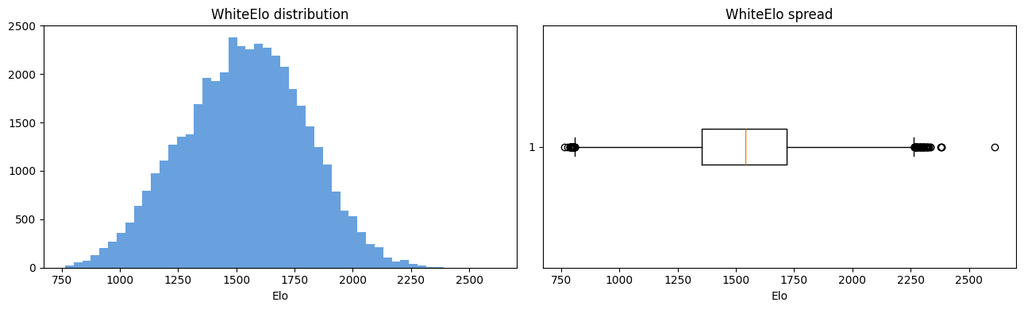

```python
y = df[TARGET].values
print(f'Target = {TARGET}  |  n = {len(y):,}')
print(pd.Series(y).describe().round(1).to_string())
print('skew:', round(float(pd.Series(y).skew()), 3), ' kurtosis:', round(float(pd.Series(y).kurtosis()), 3))

fig, ax = plt.subplots(1, 2, figsize=(13, 4))
ax[0].hist(y, bins=50, color='#4e91d9', alpha=0.85); ax[0].set_title(f'{TARGET} distribution'); ax[0].set_xlabel('Elo')
ax[1].boxplot(y, vert=False); ax[1].set_title(f'{TARGET} spread'); ax[1].set_xlabel('Elo')
plt.tight_layout(); plt.savefig(f'{RESULTS_DIR}/target_distribution_{_TS}.png', dpi=110); plt.show()
```

```python
# Missingness per feature (NaN means imputed downstream — worth knowing how much)
miss = df[NUM_COLS].isna().mean().sort_values(ascending=False)
miss = miss[miss > 0]
if len(miss):
    print('Features with missing values (fraction):')
    print(miss.round(4).to_string())
else:
    print('No missing values in the active numeric features.')
```

```
No missing values in the active numeric features.
```

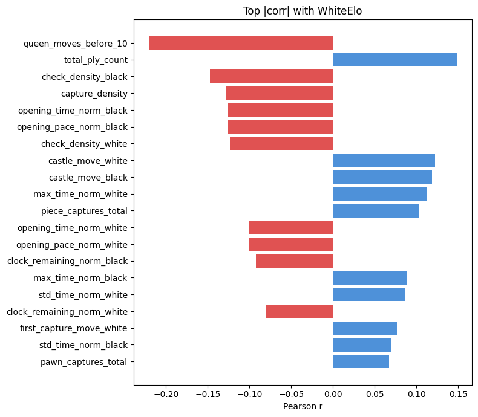

```
Strongest correlates:
queen_moves_before_10        -0.220
total_ply_count               0.148
check_density_black          -0.147
capture_density              -0.129
opening_time_norm_black      -0.127
opening_pace_norm_black      -0.127
check_density_white          -0.124
castle_move_white             0.122
castle_move_black             0.119
max_time_norm_white           0.113
piece_captures_total          0.103
opening_time_norm_white      -0.101
opening_pace_norm_white      -0.101
clock_remaining_norm_black   -0.092
max_time_norm_black           0.089
std_time_norm_white           0.086
clock_remaining_norm_white   -0.081
first_capture_move_white      0.077
std_time_norm_black           0.069
pawn_captures_total           0.067
```

```python
# Feature–target correlation (which raw features carry signal about Elo?)
corr_target = df[NUM_COLS].corrwith(df[TARGET]).sort_values(key=np.abs, ascending=False)
top = corr_target.head(TOP_N_FEATURES)
fig, ax = plt.subplots(figsize=(8, max(4, 0.35*len(top))))
colors = ['#e05252' if v < 0 else '#4e91d9' for v in top.values]
ax.barh(top.index[::-1], top.values[::-1], color=colors[::-1])
ax.axvline(0, color='k', lw=0.6); ax.set_title(f'Top |corr| with {TARGET}'); ax.set_xlabel('Pearson r')
plt.tight_layout(); plt.savefig(f'{RESULTS_DIR}/feature_target_corr_{_TS}.png', dpi=110); plt.show()
print('Strongest correlates:'); print(top.round(3).to_string())
```

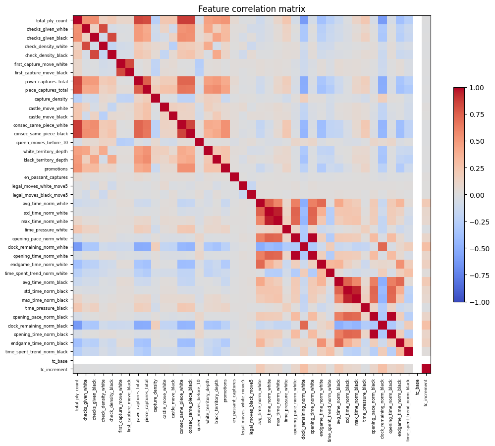

```
Highly correlated pairs (|r| > 0.9) — candidates to prune:
opening_pace_norm_white  opening_time_norm_white    1.000
opening_pace_norm_black  opening_time_norm_black    1.000
std_time_norm_white      max_time_norm_white        0.947
std_time_norm_black      max_time_norm_black        0.945
```

```python
# Multicollinearity: feature-feature correlation heatmap + flag highly-correlated pairs
cmat = df[NUM_COLS].corr()
fig, ax = plt.subplots(figsize=(11, 9))
if HAS_SNS:
    sns.heatmap(cmat, cmap='coolwarm', center=0, ax=ax, cbar_kws={'shrink': .6})
else:
    im = ax.imshow(cmat, cmap='coolwarm', vmin=-1, vmax=1); fig.colorbar(im, shrink=.6)
    ax.set_xticks(range(len(NUM_COLS))); ax.set_xticklabels(NUM_COLS, rotation=90, fontsize=6)
    ax.set_yticks(range(len(NUM_COLS))); ax.set_yticklabels(NUM_COLS, fontsize=6)
ax.set_title('Feature correlation matrix'); plt.tight_layout()
plt.savefig(f'{RESULTS_DIR}/feature_corr_heatmap_{_TS}.png', dpi=110); plt.show()

upper = cmat.where(np.triu(np.ones(cmat.shape), k=1).astype(bool)).stack()
high = upper[upper.abs() > 0.9].sort_values(key=np.abs, ascending=False)
print('Highly correlated pairs (|r| > 0.9) — candidates to prune:')
print(high.round(3).to_string() if len(high) else '  none')
```

```python
# Explicit leakage check: correlation of the result/material features with the target.
# These describe the OUTCOME of the game, not the players' skill, so a high |r| here is
# a red flag that the model could 'cheat'. DROP_RESULT_LEAKAGE controls whether they are used.
for c in ['result_encoded', 'material_balance_end']:
    if c in df.columns:
        print(f'{c:24s} corr with {TARGET}: {df[c].corr(df[TARGET]):+.3f}')
print(f'\nDROP_RESULT_LEAKAGE = {DROP_RESULT_LEAKAGE} (these features are {"excluded" if DROP_RESULT_LEAKAGE else "INCLUDED"} from X)')
```

```
result_encoded           corr with WhiteElo: +0.057
material_balance_end     corr with WhiteElo: +0.037

DROP_RESULT_LEAKAGE = True (these features are excluded from X)
```

## 4 · Train / Val / Test split + sample weights

Inverse-frequency Elo weights so the rare high/low-rated games are not ignored.

```python
idx = np.arange(len(df))
idx_tv, idx_test = train_test_split(idx, test_size=TEST_SIZE, random_state=RANDOM_STATE)
idx_train, idx_val = train_test_split(idx_tv, test_size=VAL_SIZE/(1-TEST_SIZE), random_state=RANDOM_STATE)

X_df = df[NUM_COLS + CAT_COLS]
X_train_df, X_val_df, X_test_df = X_df.iloc[idx_train], X_df.iloc[idx_val], X_df.iloc[idx_test]
y_train, y_val, y_test = y[idx_train], y[idx_val], y[idx_test]

_pct = np.percentile(y, [0,10,25,50,75,90,95,99,100])
ELO_BINS = sorted(set(int(x) for x in _pct))
w_full = np.clip(compute_elo_sample_weights(df[TARGET], ELO_BINS), 0, 8.0)
w_train = w_full[idx_train]
print(f'Train {len(idx_train):,} | Val {len(idx_val):,} | Test {len(idx_test):,}')
```

```
Train 34,246 | Val 4,281 | Test 4,281
```

## 5 · Model zoo + cross-validated bake-off

Each model is a full `Pipeline(preprocessor + estimator)` so preprocessing is fit inside every CV fold (no leakage across folds). Linear models get scaling; trees do not.

```python
def make_model(name):
    """Return (pipeline, needs_scaling)."""
    if name == 'dummy':
        return DummyRegressor(strategy='mean'), False
    if name == 'ridge':
        return Ridge(alpha=10.0, random_state=RANDOM_STATE), True
    if name == 'random_forest':
        return RandomForestRegressor(n_estimators=200, max_depth=None, min_samples_leaf=5,
                                     n_jobs=N_JOBS, random_state=RANDOM_STATE), False
    if name == 'hist_gbm':
        return HistGradientBoostingRegressor(max_iter=400, learning_rate=0.05,
                                             max_leaf_nodes=63, random_state=RANDOM_STATE), False
    if name == 'lightgbm':
        return lgb.LGBMRegressor(n_estimators=500, learning_rate=0.05, num_leaves=63,
                                 min_child_samples=20, subsample=0.8, colsample_bytree=0.8,
                                 random_state=RANDOM_STATE, verbose=-1, n_jobs=N_JOBS), False
    if name == 'xgboost':
        return xgb.XGBRegressor(n_estimators=500, learning_rate=0.05, max_depth=8,
                                subsample=0.8, colsample_bytree=0.8, tree_method='hist',
                                random_state=RANDOM_STATE, n_jobs=N_JOBS), False
    raise ValueError(name)

def build_pipeline(name):
    est, scale = make_model(name)
    pre = make_preprocessor(NUM_COLS, CAT_COLS, scale=scale)
    return Pipeline([('pre', pre), ('model', est)])

scoring = {'mae': 'neg_mean_absolute_error', 'rmse': 'neg_root_mean_squared_error', 'r2': 'r2'}
cv = KFold(n_splits=CV_FOLDS, shuffle=True, random_state=RANDOM_STATE)

cv_rows = []
for name in MODELS_TO_RUN:
    t0 = time.time()
    pipe = build_pipeline(name)
    res = cross_validate(pipe, X_train_df, y_train, cv=cv, scoring=scoring, n_jobs=1 if name in ('random_forest','lightgbm','xgboost') else N_JOBS)
    cv_rows.append({
        'model': name,
        'MAE': -res['test_mae'].mean(), 'MAE_std': res['test_mae'].std(),
        'RMSE': -res['test_rmse'].mean(), 'R2': res['test_r2'].mean(),
        'fit_s': time.time()-t0,
    })
    print(f"{name:15s} MAE {cv_rows[-1]['MAE']:6.1f} ± {cv_rows[-1]['MAE_std']:4.1f}  RMSE {cv_rows[-1]['RMSE']:6.1f}  R2 {cv_rows[-1]['R2']:.3f}  ({cv_rows[-1]['fit_s']:.0f}s)")

cv_df = pd.DataFrame(cv_rows).sort_values('MAE').reset_index(drop=True)
cv_df.to_csv(f'{RESULTS_DIR}/model_comparison_{_TS}.csv', index=False)
cv_df.round(3)
```

```
dummy           MAE  212.2 ±  1.8  RMSE  262.1  R2 -0.000  (5s)
ridge           MAE  179.5 ±  1.1  RMSE  225.5  R2 0.259  (1s)
random_forest   MAE  180.6 ±  1.0  RMSE  226.4  R2 0.254  (101s)
hist_gbm        MAE  175.3 ±  1.0  RMSE  220.4  R2 0.293  (12s)
lightgbm        MAE  175.1 ±  1.3  RMSE  220.4  R2 0.293  (13s)
xgboost         MAE  175.8 ±  1.0  RMSE  221.1  R2 0.288  (27s)
```

|  | model | MAE | MAE_std | RMSE | R2 | fit_s |
| --- | --- | --- | --- | --- | --- | --- |
| 0 | lightgbm | 175.137 | 1.258 | 220.355 | 0.293 | 13.142 |
| 1 | hist_gbm | 175.336 | 0.972 | 220.435 | 0.293 | 11.782 |
| 2 | xgboost | 175.755 | 1.031 | 221.100 | 0.288 | 27.243 |
| 3 | ridge | 179.484 | 1.120 | 225.546 | 0.259 | 0.991 |
| 4 | random_forest | 180.617 | 0.964 | 226.433 | 0.254 | 101.367 |
| 5 | dummy | 212.209 | 1.755 | 262.122 | -0.000 | 4.522 |

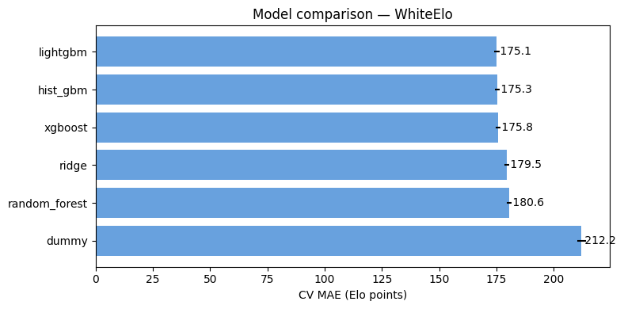

```
Best model by CV MAE: lightgbm
```

```python
# Visual bake-off: CV MAE with error bars (lower is better). Dummy = naive baseline.
plot_df = cv_df.sort_values('MAE', ascending=False)
fig, ax = plt.subplots(figsize=(8, 4))
ax.barh(plot_df['model'], plot_df['MAE'], xerr=plot_df['MAE_std'], color='#4e91d9', alpha=0.85)
ax.set_xlabel('CV MAE (Elo points)'); ax.set_title(f'Model comparison — {TARGET}')
for i, (m, v) in enumerate(zip(plot_df['model'], plot_df['MAE'])):
    ax.text(v, i, f' {v:.1f}', va='center')
plt.tight_layout(); plt.savefig(f'{RESULTS_DIR}/model_comparison_{_TS}.png', dpi=110); plt.show()

BEST_MODEL = cv_df.iloc[0]['model'] if cv_df.iloc[0]['model'] != 'dummy' else cv_df.iloc[1]['model']
print('Best model by CV MAE:', BEST_MODEL)
```

## 6 · Hyperparameter search (toggle `RUN_HYPERPARAM_SEARCH`)

This is the slow part. Two speed-ups are built in: (1) `HYPERPARAM_STRATEGY='halving'` uses successive halving which trains many configs cheaply on small subsets first; (2) `HYPERPARAM_MAX_ROWS` sub-samples the training rows for the search only.

```python
SEARCH_SPACES = {
    'lightgbm': {
        'model__n_estimators': randint(200, 900), 'model__learning_rate': uniform(0.01, 0.1),
        'model__num_leaves': randint(31, 160), 'model__min_child_samples': randint(10, 60),
        'model__subsample': uniform(0.6, 0.4), 'model__colsample_bytree': uniform(0.6, 0.4),
    },
    'hist_gbm': {
        'model__max_iter': randint(200, 800), 'model__learning_rate': uniform(0.01, 0.15),
        'model__max_leaf_nodes': randint(15, 127), 'model__min_samples_leaf': randint(10, 60),
    },
    'random_forest': {
        'model__n_estimators': randint(100, 400), 'model__max_depth': randint(6, 30),
        'model__min_samples_leaf': randint(2, 20), 'model__max_features': uniform(0.3, 0.7),
    },
    'ridge': {'model__alpha': uniform(0.1, 100.0)},
}

best_params = None
if RUN_HYPERPARAM_SEARCH:
    space = SEARCH_SPACES[HYPERPARAM_MODEL]
    pipe = build_pipeline(HYPERPARAM_MODEL)
    # sub-sample rows for speed
    if HYPERPARAM_MAX_ROWS and len(X_train_df) > HYPERPARAM_MAX_ROWS:
        rng = np.random.RandomState(RANDOM_STATE)
        sub = rng.choice(len(X_train_df), HYPERPARAM_MAX_ROWS, replace=False)
        Xs, ys = X_train_df.iloc[sub], y_train[sub]
    else:
        Xs, ys = X_train_df, y_train
    t0 = time.time()
    if HYPERPARAM_STRATEGY == 'halving':
        from sklearn.experimental import enable_halving_search_cv  # noqa
        from sklearn.model_selection import HalvingRandomSearchCV
        search = HalvingRandomSearchCV(pipe, space, factor=3, cv=HYPERPARAM_CV_FOLDS,
                                       scoring='neg_mean_absolute_error', random_state=RANDOM_STATE,
                                       n_jobs=N_JOBS, verbose=1)
    else:
        search = RandomizedSearchCV(pipe, space, n_iter=HYPERPARAM_N_ITER, cv=HYPERPARAM_CV_FOLDS,
                                    scoring='neg_mean_absolute_error', random_state=RANDOM_STATE,
                                    n_jobs=N_JOBS, verbose=1)
    search.fit(Xs, ys)
    best_params = {k.replace('model__',''): v for k, v in search.best_params_.items()}
    print(f'Search done in {time.time()-t0:.0f}s. Best CV MAE: {-search.best_score_:.1f}')
    print('Best params:', best_params)
    with open(f'{RESULTS_DIR}/best_params_{HYPERPARAM_MODEL}_{_TS}.json', 'w') as f:
        json.dump(best_params, f, indent=2, default=str)
else:
    print('Hyperparameter search skipped (RUN_HYPERPARAM_SEARCH = False)')
```

```
Hyperparameter search skipped (RUN_HYPERPARAM_SEARCH = False)
```

## 7 · Fit the best model + diagnostics on the held-out test set

```python
final_pipe = build_pipeline(BEST_MODEL)
if best_params and RUN_HYPERPARAM_SEARCH and HYPERPARAM_MODEL == BEST_MODEL:
    final_pipe.named_steps['model'].set_params(**best_params)

fit_kwargs = {}
# sample weights only for estimators that accept them
if BEST_MODEL in ('ridge','random_forest','lightgbm','xgboost','hist_gbm'):
    fit_kwargs['model__sample_weight'] = w_train
final_pipe.fit(X_train_df, y_train, **fit_kwargs)

test_pred = final_pipe.predict(X_test_df)
print(f'TEST  MAE {mean_absolute_error(y_test, test_pred):.1f}  '
      f'RMSE {root_mean_squared_error(y_test, test_pred):.1f}  '
      f'R2 {r2_score(y_test, test_pred):.3f}')
```

```
TEST  MAE 180.0  RMSE 226.1  R2 0.240
```

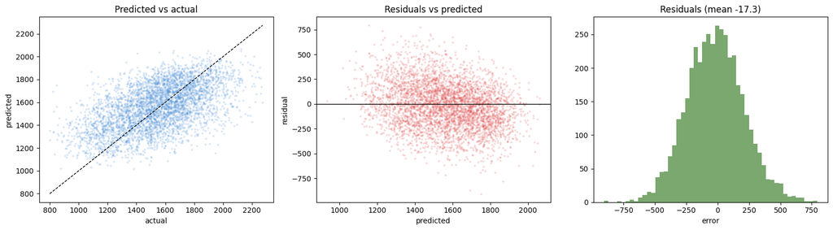

```python
# Predicted vs actual + residuals
resid = y_test - test_pred
fig, ax = plt.subplots(1, 3, figsize=(16, 4.5))
ax[0].scatter(y_test, test_pred, s=4, alpha=0.15, color='#4e91d9')
lims = [min(y_test.min(), test_pred.min()), max(y_test.max(), test_pred.max())]
ax[0].plot(lims, lims, 'k--', lw=1); ax[0].set_xlabel('actual'); ax[0].set_ylabel('predicted'); ax[0].set_title('Predicted vs actual')
ax[1].scatter(test_pred, resid, s=4, alpha=0.15, color='#e05252'); ax[1].axhline(0, color='k', lw=1)
ax[1].set_xlabel('predicted'); ax[1].set_ylabel('residual'); ax[1].set_title('Residuals vs predicted')
ax[2].hist(resid, bins=50, color='#7aa86f'); ax[2].set_title(f'Residuals (mean {resid.mean():+.1f})'); ax[2].set_xlabel('error')
plt.tight_layout(); plt.savefig(f'{RESULTS_DIR}/diagnostics_{BEST_MODEL}_{_TS}.png', dpi=110); plt.show()
```

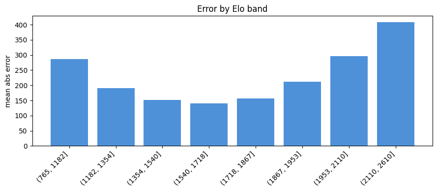

```
               mean  count
band
(765, 1182]   286.9    419
(1182, 1354]  191.5    611
(1354, 1540]  151.3   1025
(1540, 1718]  140.8   1150
(1718, 1867]  155.8    626
(1867, 1953]  212.1    229
(1953, 2110]  296.0    177
(2110, 2610]  408.5     44
```

```python
# Error by Elo band — shows where the model struggles (usually the rating extremes)
band = pd.cut(y_test, bins=ELO_BINS)
err_by_band = pd.DataFrame({'abs_err': np.abs(resid), 'band': band}).groupby('band', observed=True)['abs_err'].agg(['mean','count'])
fig, ax = plt.subplots(figsize=(9, 4))
ax.bar([str(b) for b in err_by_band.index], err_by_band['mean'], color='#4e91d9')
ax.set_ylabel('mean abs error'); ax.set_title('Error by Elo band'); plt.xticks(rotation=45, ha='right')
plt.tight_layout(); plt.savefig(f'{RESULTS_DIR}/error_by_band_{_TS}.png', dpi=110); plt.show()
print(err_by_band.round(1).to_string())
```

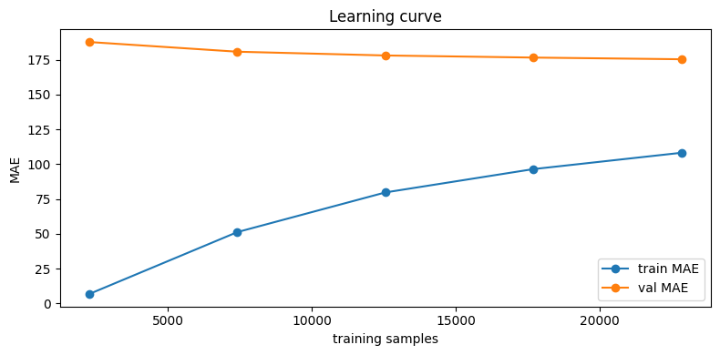

```python
# Learning curve — are we data-bound or model-bound? (use a subsample for speed)
lc_n = min(40_000, len(X_train_df))
rng = np.random.RandomState(RANDOM_STATE)
lc_idx = rng.choice(len(X_train_df), lc_n, replace=False)
sizes, train_sc, val_sc = learning_curve(
    build_pipeline(BEST_MODEL), X_train_df.iloc[lc_idx], y_train[lc_idx],
    train_sizes=np.linspace(0.1, 1.0, 5), cv=3, scoring='neg_mean_absolute_error', n_jobs=1)
fig, ax = plt.subplots(figsize=(8, 4))
ax.plot(sizes, -train_sc.mean(1), 'o-', label='train MAE')
ax.plot(sizes, -val_sc.mean(1), 'o-', label='val MAE')
ax.set_xlabel('training samples'); ax.set_ylabel('MAE'); ax.set_title('Learning curve'); ax.legend()
plt.tight_layout(); plt.savefig(f'{RESULTS_DIR}/learning_curve_{_TS}.png', dpi=110); plt.show()
```

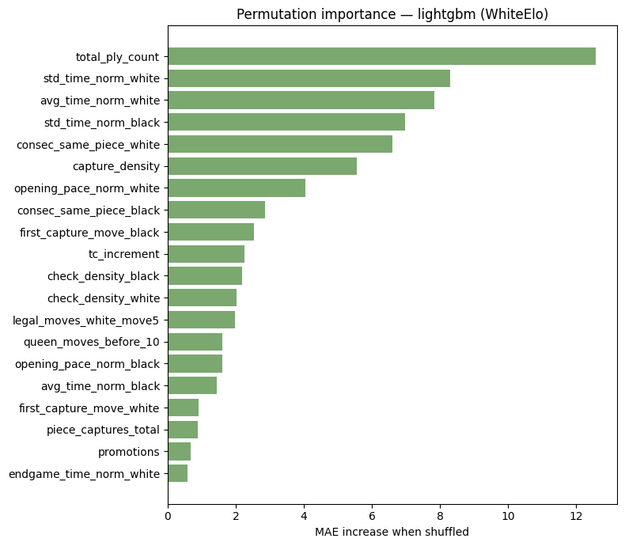

|  | importance |
| --- | --- |
| total_ply_count | 12.582 |
| std_time_norm_white | 8.312 |
| avg_time_norm_white | 7.843 |
| std_time_norm_black | 6.981 |
| consec_same_piece_white | 6.609 |
| capture_density | 5.557 |
| opening_pace_norm_white | 4.040 |
| consec_same_piece_black | 2.867 |
| first_capture_move_black | 2.537 |
| tc_increment | 2.253 |
| check_density_black | 2.180 |
| check_density_white | 2.034 |
| legal_moves_white_move5 | 1.978 |
| queen_moves_before_10 | 1.609 |
| opening_pace_norm_black | 1.601 |
| avg_time_norm_black | 1.445 |
| first_capture_move_white | 0.903 |
| piece_captures_total | 0.876 |
| promotions | 0.677 |
| endgame_time_norm_white | 0.571 |

```python
# Permutation importance on the test set (model-agnostic, honest importance)
pi_n = min(8000, len(X_test_df))
pi = permutation_importance(final_pipe, X_test_df.iloc[:pi_n], y_test[:pi_n],
                            n_repeats=PERM_N_REPEATS, random_state=RANDOM_STATE,
                            scoring='neg_mean_absolute_error', n_jobs=N_JOBS)
feat_in = NUM_COLS + CAT_COLS
imp = pd.Series(pi.importances_mean, index=feat_in).sort_values(ascending=False).head(TOP_N_FEATURES)
fig, ax = plt.subplots(figsize=(8, max(4, 0.35*len(imp))))
ax.barh(imp.index[::-1], imp.values[::-1], color='#7aa86f')
ax.set_title(f'Permutation importance — {BEST_MODEL} ({TARGET})'); ax.set_xlabel('MAE increase when shuffled')
plt.tight_layout(); plt.savefig(f'{RESULTS_DIR}/perm_importance_{_TS}.png', dpi=110); plt.show()
imp.round(3).to_frame('importance')
```

## 8 · Feature-ranking comparison across time controls

For each time control we rebuild features, fit the best model, and compute permutation importance. Then we compare which features dominate in bullet vs blitz vs rapid — e.g. clock features should matter more in faster games.

```python
def rank_features_for_tc(base_seconds, max_rows=120_000):
    sub = df_all
    dft = build_feature_frame(sub, FEATURE_GROUPS, base_seconds)
    if len(dft) < 2000:
        print(f'  TC {base_seconds}s: only {len(dft)} games, skipping'); return None
    if len(dft) > max_rows:
        dft = dft.sample(max_rows, random_state=RANDOM_STATE).reset_index(drop=True)
    num, cat = active_feature_lists(FEATURE_GROUPS, DROP_RESULT_LEAKAGE)
    num = [c for c in num if c in dft.columns]; cat = [c for c in cat if c in dft.columns]
    Xd, yt = dft[num + cat], dft[TARGET].values
    Xtr, Xte, ytr, yte = train_test_split(Xd, yt, test_size=0.2, random_state=RANDOM_STATE)
    est, scale = make_model(BEST_MODEL)
    pipe = Pipeline([('pre', make_preprocessor(num, cat, scale=scale)), ('model', est)])
    pipe.fit(Xtr, ytr)
    mae = mean_absolute_error(yte, pipe.predict(Xte))
    pi = permutation_importance(pipe, Xte.iloc[:6000], yte[:6000], n_repeats=3,
                                random_state=RANDOM_STATE, scoring='neg_mean_absolute_error', n_jobs=N_JOBS)
    s = pd.Series(pi.importances_mean, index=(num+cat))
    print(f'  TC {base_seconds}s: {len(dft):,} games, test MAE {mae:.1f}')
    return s

tc_importances = {}
for tc in TIME_CONTROLS_TO_COMPARE:
    print(f'Time control {tc}s...')
    s = rank_features_for_tc(tc)
    if s is not None:
        tc_importances[f'{tc}s'] = s

imp_df = pd.DataFrame(tc_importances).fillna(0.0)
# normalise each column so we compare relative ranking, not absolute MAE scale
imp_norm = imp_df / imp_df.sum(axis=0)
imp_df.to_csv(f'{RESULTS_DIR}/feature_importance_by_tc_{_TS}.csv')
imp_norm.round(3)
```

```
Time control 60s...
  TC 60s: 51,236 games, test MAE 179.0
Time control 180s...
  TC 180s: 71,535 games, test MAE 190.5
Time control 600s...
  TC 600s: 42,808 games, test MAE 172.3
```

|  | 60s | 180s | 600s |
| --- | --- | --- | --- |
| total_ply_count | 0.094 | 0.125 | 0.179 |
| checks_given_white | 0.001 | 0.001 | 0.000 |
| checks_given_black | 0.000 | 0.000 | 0.001 |
| check_density_white | 0.001 | 0.005 | 0.021 |
| check_density_black | 0.003 | 0.012 | 0.027 |
| first_capture_move_white | 0.021 | 0.019 | 0.015 |
| first_capture_move_black | 0.025 | 0.023 | 0.029 |
| pawn_captures_total | 0.033 | 0.019 | 0.005 |
| piece_captures_total | 0.010 | 0.009 | 0.020 |
| capture_density | 0.050 | 0.057 | 0.045 |
| castle_move_white | 0.004 | 0.006 | 0.025 |
| castle_move_black | 0.001 | 0.009 | 0.006 |
| consec_same_piece_white | 0.102 | 0.095 | 0.055 |
| consec_same_piece_black | 0.095 | 0.075 | 0.038 |
| queen_moves_before_10 | 0.003 | 0.005 | 0.026 |
| white_territory_depth | 0.002 | 0.000 | 0.002 |
| black_territory_depth | -0.000 | 0.001 | 0.009 |
| promotions | 0.003 | 0.005 | 0.003 |
| en_passant_captures | 0.001 | 0.001 | 0.001 |
| legal_moves_white_move5 | 0.008 | 0.014 | 0.018 |
| legal_moves_black_move5 | 0.003 | 0.011 | 0.007 |
| avg_time_norm_white | 0.279 | 0.131 | 0.084 |
| std_time_norm_white | 0.040 | 0.120 | 0.074 |
| max_time_norm_white | 0.007 | 0.006 | 0.020 |
| time_pressure_white | 0.002 | -0.000 | 0.001 |
| opening_pace_norm_white | 0.033 | 0.034 | 0.060 |
| clock_remaining_norm_white | 0.004 | 0.010 | 0.004 |
| opening_time_norm_white | 0.001 | 0.000 | 0.003 |
| endgame_time_norm_white | 0.007 | 0.007 | 0.006 |
| time_spent_trend_norm_white | 0.004 | 0.015 | 0.006 |
| avg_time_norm_black | 0.080 | 0.050 | 0.024 |
| std_time_norm_black | 0.017 | 0.075 | 0.065 |
| max_time_norm_black | 0.003 | 0.004 | 0.009 |
| time_pressure_black | 0.001 | 0.000 | -0.000 |
| opening_pace_norm_black | 0.026 | 0.030 | 0.044 |
| clock_remaining_norm_black | 0.006 | 0.003 | 0.006 |
| opening_time_norm_black | 0.002 | 0.003 | 0.007 |
| endgame_time_norm_black | 0.003 | 0.003 | 0.005 |
| time_spent_trend_norm_black | 0.002 | 0.007 | 0.006 |
| tc_base | 0.000 | 0.000 | 0.000 |
| tc_increment | 0.023 | 0.005 | 0.032 |
| castle_side_white | 0.002 | 0.003 | 0.005 |
| castle_side_black | 0.001 | 0.002 | 0.007 |

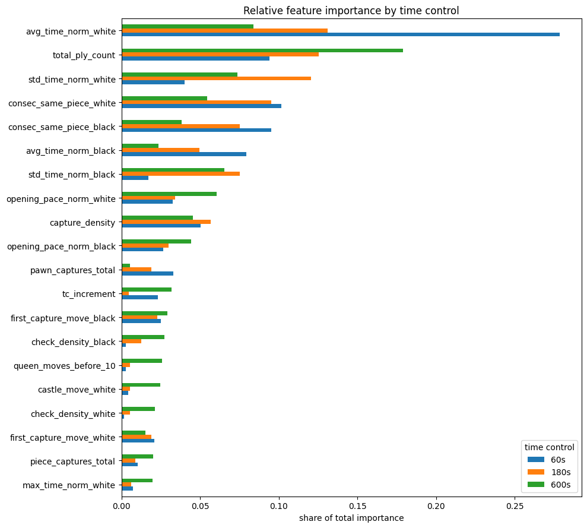

```python
# Side-by-side ranking of the top features across time controls
top_feats = imp_norm.max(axis=1).sort_values(ascending=False).head(TOP_N_FEATURES).index
plot = imp_norm.loc[top_feats][::-1]
fig, ax = plt.subplots(figsize=(10, max(5, 0.45*len(top_feats))))
plot.plot.barh(ax=ax)
ax.set_title('Relative feature importance by time control'); ax.set_xlabel('share of total importance')
ax.legend(title='time control')
plt.tight_layout(); plt.savefig(f'{RESULTS_DIR}/feature_importance_by_tc_{_TS}.png', dpi=110); plt.show()
```

## 9 · Save the executed notebook to HTML

```python
# Option A (recommended): export the ALREADY-RUN notebook to HTML without re-running.
# Run this from a terminal after the notebook finishes, or via the line below.
if EXPORT_HTML:
    out = f'{RESULTS_DIR}/{NOTEBOOK_NAME.replace(".ipynb","")}_{_TS}.html'
    # --no-input optional; keep inputs so a grader sees the code + outputs.
    cmd = f'jupyter nbconvert --to html "{NOTEBOOK_NAME}" --output "{os.path.abspath(out)}"'
    print('Run this to export with current outputs:')
    print(' ', cmd)
    # To re-execute headlessly and capture fresh outputs instead, use:
    #   jupyter nbconvert --to html --execute --ExecutePreprocessor.timeout=-1 chess_elo_prediction.ipynb
    ret = os.system(cmd)
    print('nbconvert exit code:', ret, '→', out if ret == 0 else 'failed (run manually)')
```

```
Run this to export with current outputs:
  jupyter nbconvert --to html "chess_elo_prediction.ipynb" --output "c:\Users\villa\Desktop\Masters\AppML_FinalProject\root\workspace\villads_sandbox\results\chess_elo_prediction_20260608_110616.html"
nbconvert exit code: 0 → results/chess_elo_prediction_20260608_110616.html
```